# Abstract

# **Methodology**

## SARIMA (p, d, q) x (P, D, Q) Model

The SARIMA model, which stands for Seasonal Autoregressive Integrated Moving Average, extends the ARIMA model to accommodate data with a seasonal component.

1. **Model Components**:
   - $p$: Order of the non-seasonal autoregre[ssive (AR) part.
   - $d$: Degree of non-seasonal differencing.
   - $q$: Order of the non-seasonal moving average (MA) part.
   - $P$: Order of the seasonal autoregressive (SAR) part.
   - $D$: Degree of seasonal differencing.
   - $Q$: Order of the seasonal moving average (SMA) part.
   - $s$: Length of the seasonal cycle.
2. **Model Definition**: The SARIMA model incorporates both non-seasonal and seasonal components. It can be expressed as:
   $$\Phi_P(B^s) \phi(B) \nabla^D_s \nabla^d x_t = \Theta_Q(B^s) \theta(B)
   w_t$$
   where:
   - $\phi(B)$ and $\theta(B)$ are polynomials representing the non-seasonal AR and MA components, respectively.
   - $\Phi_P(B^s)$ and $\Theta_Q(B^s)$ are polynomials representing the seasonal AR and MA components, respectively.
   - $\nabla^d = (1 - B)^d$ represents non-seasonal differencing.
   - $\nabla^D_s = (1 - B^s)^D$ represents seasonal differencing.
   - $w_t$ is white noise.
3. **Seasonal Differencing**: Seasonal differencing is applied to remove seasonality from the data. A seasonal difference of order $D$ is defined as:
   $$\nabla^D_s x_t = (1 - B^s)^D x_t$$
   This is typically done when the autocorrelation function (ACF) shows significant spikes at multiples of the seasonal period.
4. **Parameter Estimation**: The parameters of the SARIMA model are estimated using methods like maximum likelihood estimation (MLE). The process involves fitting the model to the data by finding the values of $p, d, q, P, D, Q$ that minimize the prediction error.
5. **Model Diagnostics**: Once the model is fitted, it is essential to check the residuals to ensure they resemble white noise. Diagnostic checks include:
   - Analyzing the residual ACF and partial ACF (PACF) plots.
   - Performing statistical tests like the Ljung-Box test to check for autocorrelation.
6. **Model Selection**: Model selection criteria such as the Akaike Information Criterion (AIC) or the Bayesian Information Criterion (BIC) are used to compare different SARIMA models. The model with the lowest AIC or BIC is generally preferred.

## Spectral Analysis

The spectral analysis of time series data is an tool taht focuses on analyzing the frequency components of time series to identify periodicities, trends, and other characteristics that are not apparent in the time-domain.

1. **Preprocessing**

- **Detrending**: Removing the trend component of the time series, making it stationary. This is often done using differencing or regression techniques.
- **Smoothing**: Applying moving averages or other smoothing techniques to reduce noise and highlight significant signals.

2. **Transformation**

- **Periodogram**: Computing the periodogram, which estimates the spectral density of a series. It is essentially the squared norm of the transformed data, showing the power of each frequency component.

3. **Spectral Density Estimation**

- **Parametric Methods**: Fitting models like ARIMA (AutoRegressive Integrated Moving Average), where the spectral density is derived from the model parameters. This approach assumes that the data can be effectively modeled by a linear process.

4. **Analysis**

- **Identifying Peaks**: Analyzing the spectral density to identify dominant frequencies which indicate regular cycles in the data.

5. **Interpretation**

- **Interpreting Peaks**: Peaks in the spectral density can be interpreted as cycles or periodic components in the time series data.

6. **Application**

- **Forecasting**: Using the identified models and frequency components for forecasting future values of the time series.

7. **Validation**

- **Model Validation**: Validating the spectral model by checking its predictive power or its consistency with known or expected behavior of the system being modeled.

# **Results**

## SARIMA (p, d, q) x (P, D, Q)

First for the SARIMA model we will plot our time series data using the `ts()` function. Looking at the graph we can see thay our data looks pretty stationary so we will not need to take the difference of our data. However, we should check if we will need to normalize our data by using a Q-Q plot. After checking the Q-Q plot to see if we will need to log-transform the data. We can see that our data set is not normal, so we will need to log transform the data.

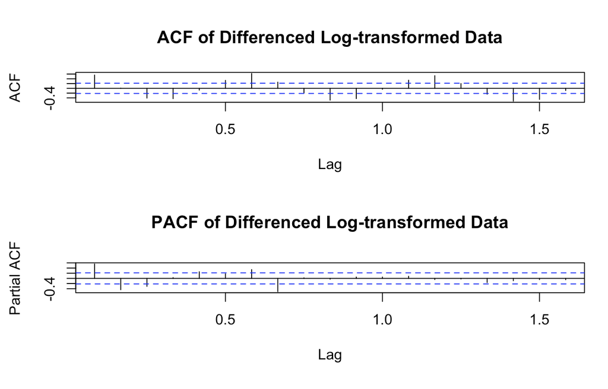

After we have log transform we will than graph the ACF and PACF to find the lag for q and p. We can see form the plot `p = 8` and `q = 6` we will fit it into the `auto.arima()` function. By fitting it into the `auto.arima()` function, we will get the optimizated ARIMA which is (2,0,2). After we have selected our best model we will graphs the model with the `sarima()` function. This will allow us to analyze our results.

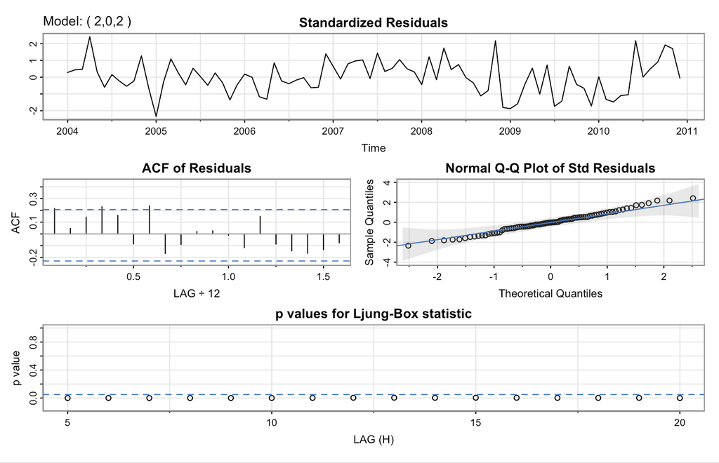

Now we will analyze the results. The results that that has been provided displays four different diagnostic plots related to the evaluation of an ARIMA (Autoregressive Integrated Moving Average) model with parameters (2,0,2).

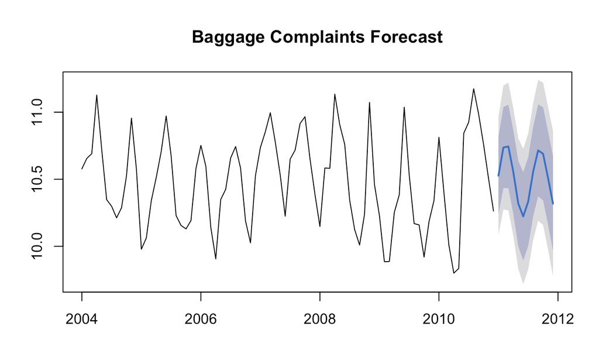

Now this would not be a time series if we did not use our model result to forecast future trend.

## Spectral Analysis

Spectral Analysis is the decomposition of a time series into underlying sine and cosine functions of different frequencies, which allows us to determine those frequencies that appear particularly strong or important. By applying Spectral Analysis to a data set it involves examining the frequency domain properties of the data. Spectral analysis helps identify dominant cycles and periodicities in the time series.

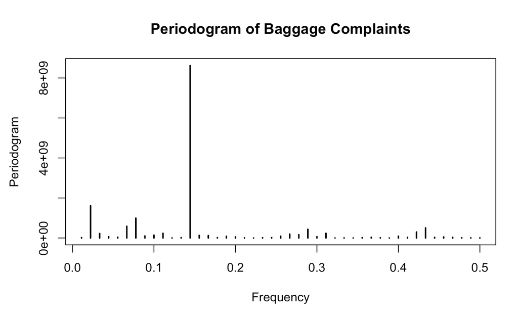

To analyze the periodogram graph we have to understand what this graph tells us. A periodogram graph is a tool used in spectral analysis to identify the frequency components of a time series. Let’s us first try to understand the graph:

Horizontal Axis (Frequency): Represents the frequency of the time series data. It usually indicates cycles per unit of time.

Vertical Axis (Periodogram): Indicates the power or amplitude of each frequency component.

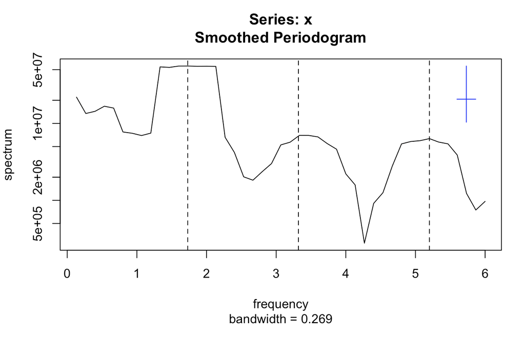

We want to smooth our graph out because to to the readability if the graph is not smooth which might show more detailed frequency components but can be noisier, while more smoothing provides a clearer view of dominant trends but can obscure finer details.

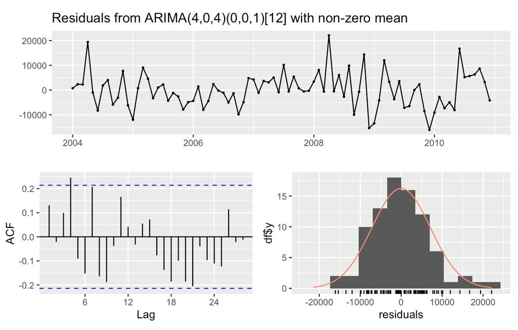

These graphs, while primarily serving as diagnostic checks for an ARIMA model, also offer valuable insights for conducting spectral analysis. The examination of these plots can reveal underlying frequency-based phenomena, such as seasonal variations or business cycles, which warrant further exploration through spectral methods.

The presence of these significant spikes in both the Residuals and ACF plots points to the potential benefits of conducting a spectral analysis. By applying spectral analysis techniques such as Fourier Transforms or calculating the spectral density, we can quantify the strength and significance of these observed frequencies.

In summary, the patterns and spikes observed in these diagnostic graphs from ARIMA modeling significantly enrich the groundwork for spectral analysis, guiding further investigations into the periodic and seasonal structures within the data.

# **Conclusion and Future Study**

For future research, extending this analysis to incorporate real-time data tracking and integrating customer satisfaction surveys would further refine the accuracy of our models. This would allow for more dynamic adjustments in airline operations, ultimately broadening the applicability of our findings in enhancing passenger experience and improving airline service management. By adapting policies based on our predictive insights, airlines can lower the incidence of baggage complaints, creating a more positive travel experience for passengers and fostering higher customer loyalty.

# **References**

Santello, Gabriel. “Airline Baggage Complaints - Time Series Dataset.” *Kaggle*, 28 Sept. 2023, www.kaggle.com/datasets/gabrielsantello/airline-baggage-complaints-time-series-dataset/data.

Shumway, R. H., & Stoffer, D. S. (n.d.). *Time Series Analysis and Its Applications With R Examples* (4th ed.). https://link.springer.com/book/10.1007/978-3-319-52452-8

# **Appendix**

## Loading the Library

```r
library(astsa)
library(forecast)
library(tseries)
library(readr)
library(tidyverse)
library(dplyr)
library(tidymodels)
library(stats)
library(TSA)
```

## Loading the Dataset

```r
baggage <- read_csv("/Users/fionhuang/Desktop/Pstat 174/Final Project/baggagecomplaints.csv")
tidymodels_prefer()
```

## SARIMA (p, d, q) x (P, D, Q)

### Plotting Original Data

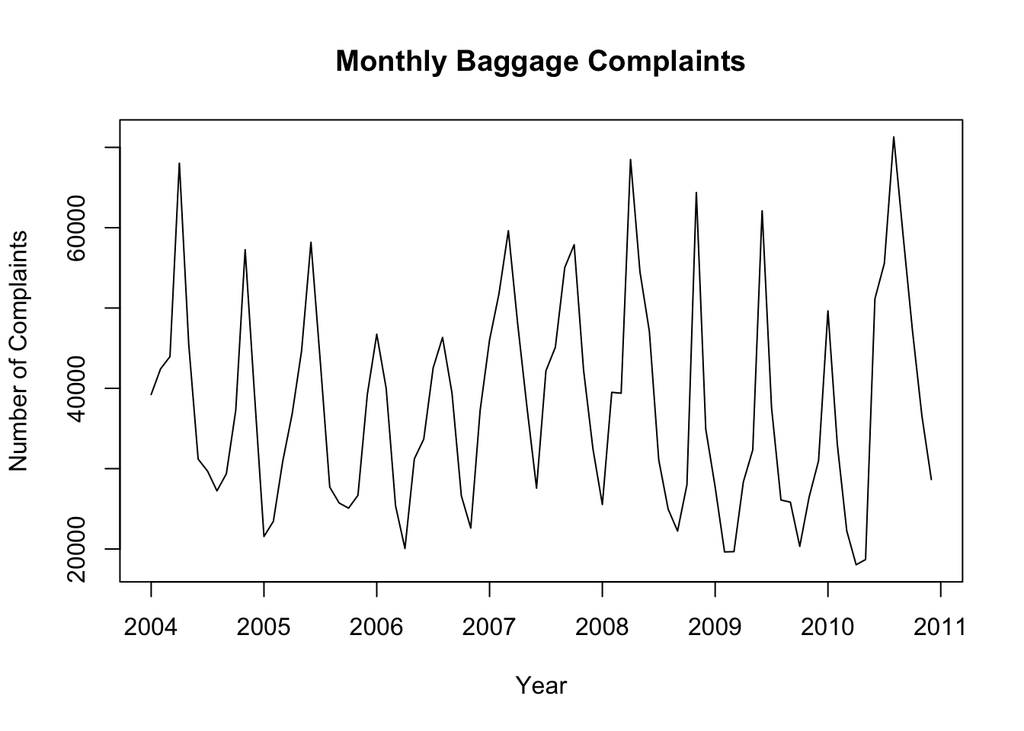

```r
set.seed(8888)

# Aggregate monthly baggage complaints
monthly_complaints <- aggregate(Baggage ~ Year + Month, baggage, sum)

# Create a time series object
ts_data <- ts(monthly_complaints$Baggage, start=c(2004, 1), frequency=12)

# Plot the time series
plot(ts_data, main='Monthly Baggage Complaints', ylab='Number of Complaints', xlab='Year')
```

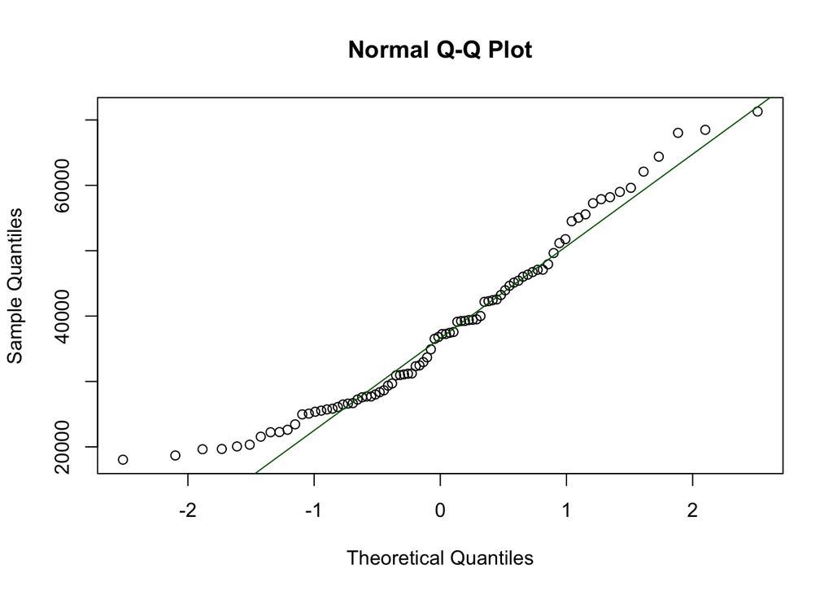

```r
set.seed(8888)

# Checking normality of dataset
qqnorm(ts_data)
qqline(ts_data, col = "darkgreen")
```

### Log-transform Data

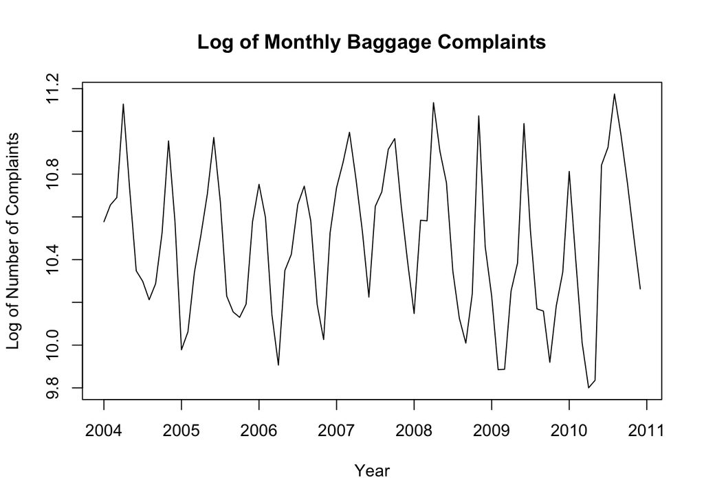

```r
set.seed(8888)

# Log transform the data because data is not normal
log_ts_data <- log(ts_data)

# Plot the log-transformed data
plot(log_ts_data, main = 'Log of Monthly Baggage Complaints',
     ylab='Log of Number of Complaints', xlab='Year')
```

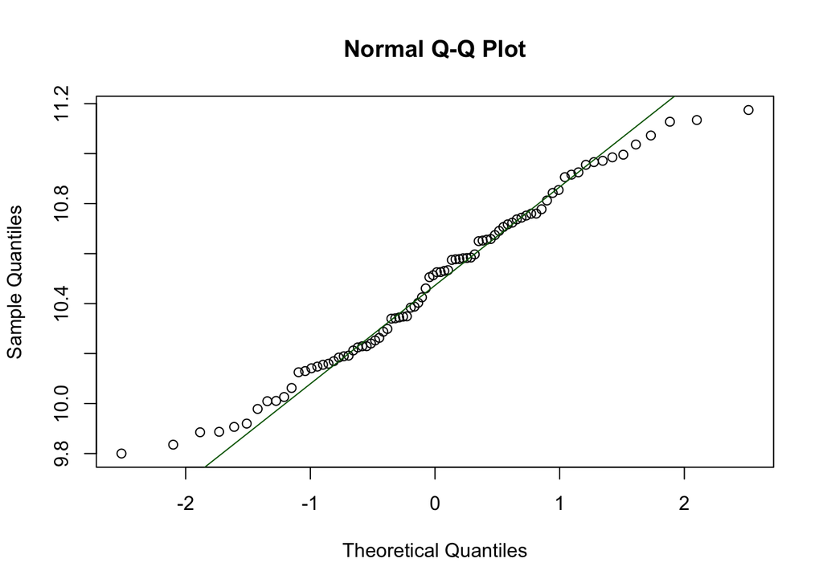

```r
# Checking normality after log-transformed
qqnorm(log_ts_data)
qqline(log_ts_data, col = "darkgreen")
```

### ACF and PACF

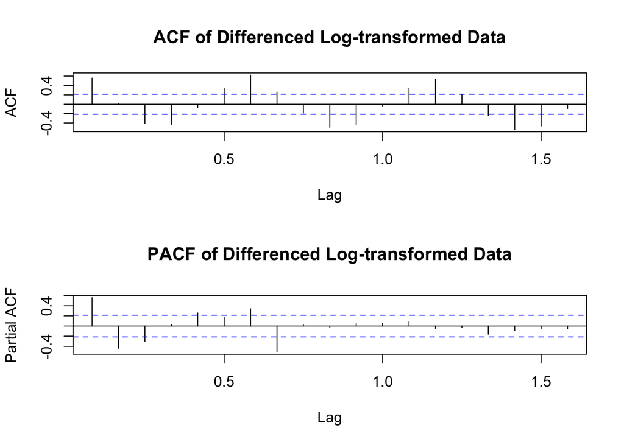

```r
set.seed(8888)

# Plot ACF and PACF
par(mfrow=c(2,1))
acf(log_ts_data, main='ACF of Differenced Log-transformed Data')
pacf(log_ts_data, main='PACF of Differenced Log-transformed Data')
```

### SARIMA model

```r
set.seed(8888)

# Fit the SARIMA model
fit1 <- auto.arima(log_ts_data, max.p = 8, max.q = 6)
```

### Estimation results

```
## <><><><><><><><><><><><><><>
##
## Coefficients:
##       Estimate     SE  t.value p.value
## ar1     1.1864 0.0359  33.0722       0
## ar2    -0.9555 0.0326 -29.2860       0
## ma1    -0.8733 0.0829 -10.5326       0
## ma2     0.8416 0.0688  12.2414       0
## xmean  10.4857 0.0300 349.2352       0
##
## sigma^2 estimated as 0.04758616 on 79 degrees of freedom
##
## AIC = -0.02792841  AICc = -0.0187709  BIC = 0.1457014
##
```

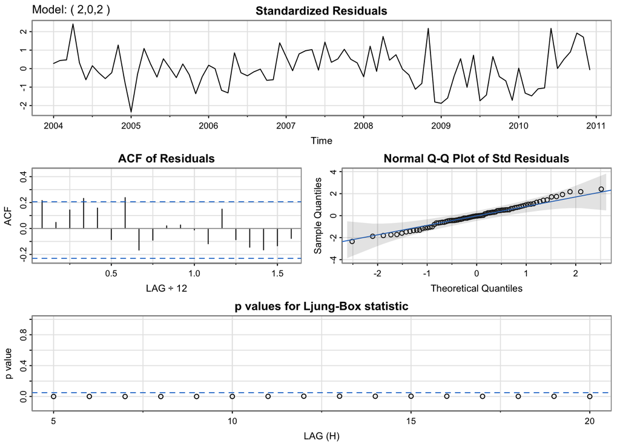

```r
sarima(log_ts_data, 2, 0, 2)
```

```r
# Display the model summary
summary(fit1)
```

```
## Series: log_ts_data
## ARIMA(2,0,2) with non-zero mean
##
## Coefficients:
##          ar1      ar2      ma1     ma2     mean
##       1.1864  -0.9555  -0.8733  0.8416  10.4857
## s.e.  0.0359   0.0326   0.0829  0.0688   0.0300
##
## sigma^2 = 0.0506:  log likelihood = 7.17
## AIC=-2.35   AICc=-1.26   BIC=12.24
##
## Training set error measures:
##                         ME      RMSE       MAE         MPE     MAPE      MASE
## Training set -0.0005071359 0.2181425 0.1720728 -0.05010382 1.643472 0.4222403
##                   ACF1
## Training set 0.2158247
```

### Forecasting

Now this would not be a time series if we did not use our model result to forecast future trend.

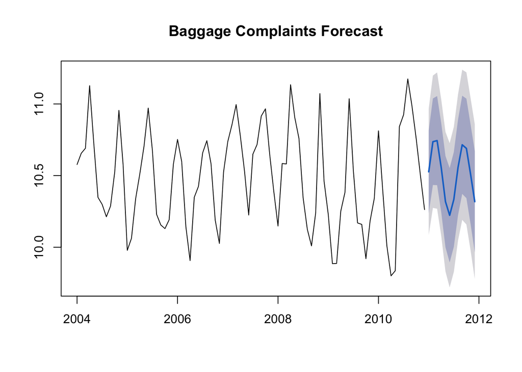

```r
library(forecast)
forecast_length <- 12
forecast <- forecast(fit1, h = forecast_length)
plot(forecast, main = "Baggage Complaints Forecast")
```

## Spectral Analysis

### Plotting Original Dataset

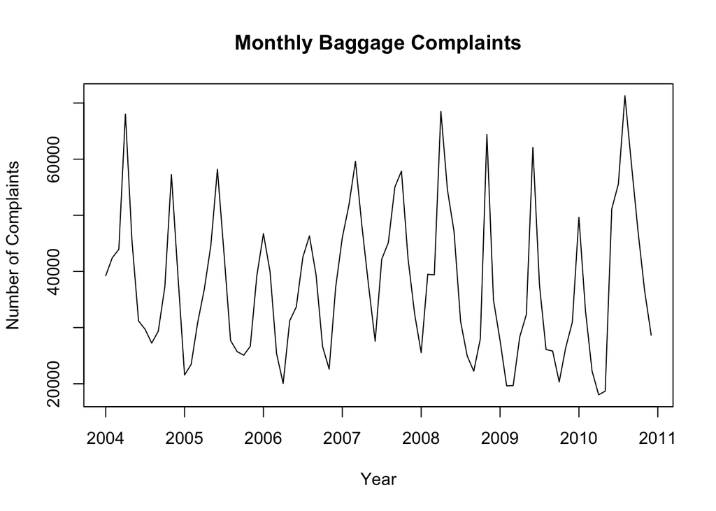

```r
# Aggregate monthly baggage complaints
monthly_complaints <- aggregate(Baggage ~ Year + Month, baggage, sum)

# Create a time series object
ts_baggage <- ts(monthly_complaints$Baggage, start=c(2004, 1), frequency=12)

# Plot the time series
plot(ts_baggage, main='Monthly Baggage Complaints', ylab='Number of Complaints', xlab='Year')
```

### Raw Periodogram

```r
# Compute log spectrum
log_baggage_spec <- mvspec(ts_baggage,taper = 0.1, log = 'y')
```

[figure not shown]

### Periodogram

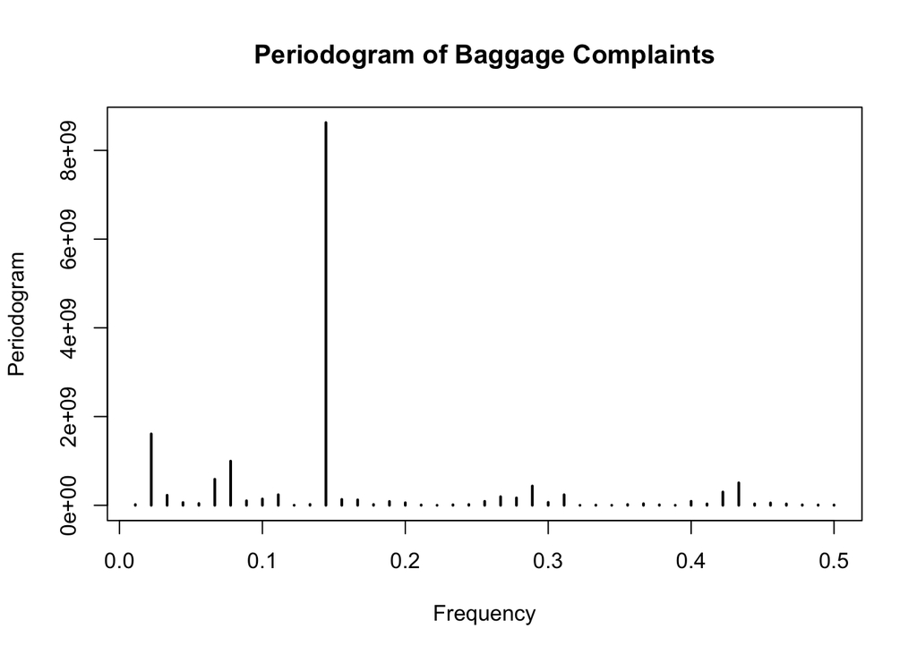

```r
# Perform periodogram
periodogram(ts_baggage, main='Periodogram of Baggage Complaints')
```

### Smoothed Periodogram

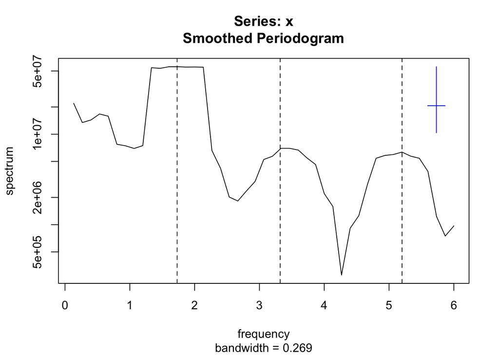

```r
# Smoothed Spectral Density Estimation
# Applying a smoothing window like the Daniell kernel
# Interpret the dominant frequencies
spec <- spectrum(ts_baggage, kernel("daniell", 3), plot = TRUE)
freq <- spec$freq
spec_density <- spec$spec

# Identify the frequency with the highest spectral density
abline(v = c(1.73, 3.32, 5.20), lty = 2)
```

```r
# Summary of the model
fit2 <- auto.arima(ts_baggage, seasonal=TRUE)
summary(fit2)
```

```
## Series: ts_baggage
## ARIMA(4,0,4)(0,0,1)[12] with non-zero mean
##
## Coefficients:
##           ar1     ar2      ar3      ar4     ma1     ma2     ma3     ma4
##       -0.5977  0.1723  -0.5133  -0.8735  1.0167  0.4296  0.8817  0.7429
## s.e.   0.0737  0.0745   0.0660   0.0617  0.1177  0.1725  0.1226  0.1057
##          sma1        mean
##       -0.5560  37852.6156
## s.e.   0.1538    619.9411
##
## sigma^2 = 57478046:  log likelihood = -868.81
## AIC=1759.63   AICc=1763.29   BIC=1786.37
##
## Training set error measures:
##                     ME     RMSE      MAE       MPE     MAPE      MASE      ACF1
## Training set -11.49807 7115.857 5436.971 -3.233427 16.10664 0.3597159 0.1306859
```

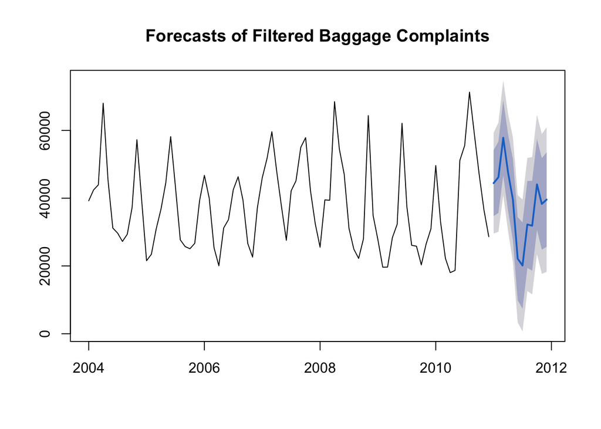

```r
# Forecasting
forecasts <- forecast(fit2, h=12) # Forecast for next 12 periods
plot(forecasts, main='Forecasts of Filtered Baggage Complaints')
```

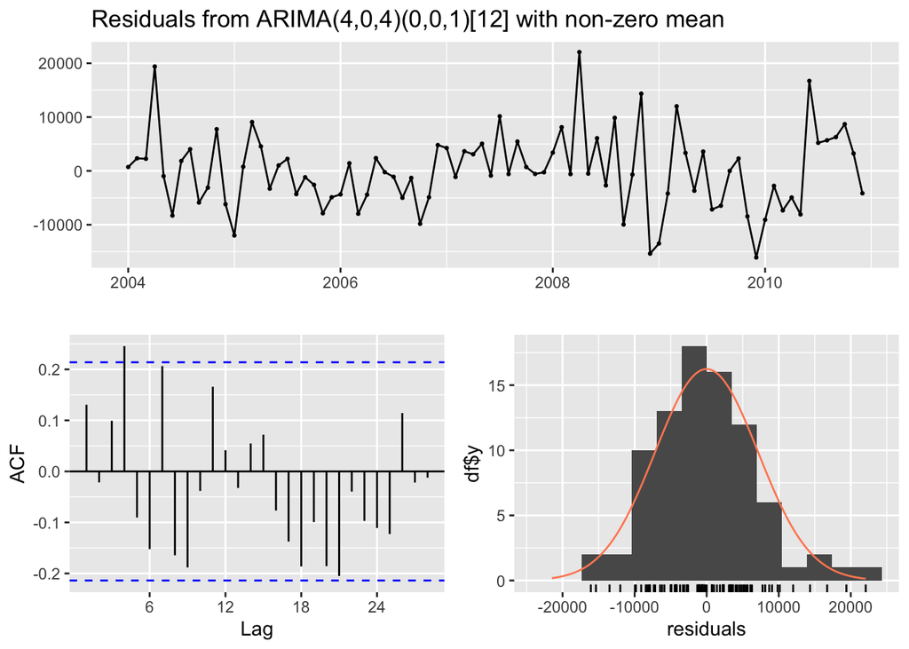

```
##
##  Ljung-Box test
##
## data:  Residuals from ARIMA(4,0,4)(0,0,1)[12] with non-zero mean
## Q* = 27.39, df = 8, p-value = 0.0006053
##
## Model df: 9.   Total lags used: 17
```

```r
# Check residuals
checkresiduals(fit2)
```